# definitivo

Enrique Roa, Miguel Ocon, Sergio fernández

13 de enero de 2023

[figure not shown]

# 1 Introducción y definición de objetivos

El análisis de datos en el deporte es un área que lleva varios años en auge, hasta el punto de que en algunos casos como el fútbol americano o el baseball ha adquirido tal relevancia que tiene influencia directa en el desarrollo de los partidos.

El mundo del fútbol, sin embargo, parece algo reacio a incorporar esta forma de trabajo en su día a día, aunque en los últimos años ya están apareciendo empresas especializadas, como es el caso de *Olocip*, que empiezan a ofrecer soluciones reales para temas que antes pasaban desapercibidos.

Nuestro primer propósito será analizar los datos en profundidad para ver cómo se distribuyen los diferentes eventos en un partido de fútbol, para posteriormente determinar cuáles son aquellos que tienen mayor influencia en el resultado final.

En ultima instancia, tras conocer aquellas variables que influyen en mayor medida en la victoria de un equipo, se intentará comprobar si es posible predecir el desenlace de un partido futuro.

```r
library(dplyr)
library(tidyr)
library(knitr)
library(readr)
library(ggplot2)
library(cowplot)
library(GGally)
library(kableExtra)
library(plotrix)
library(ggcorrplot)
```

# 2 Análisis exploratorio inicial

## 2.1 Lectura y preparación de los datos

En esta primera etapa cargamos el dataset descargado y hacemos una observación superficial de las variables recogidas y sus características. Se representan también las 10 filas iniciales (primera jornada).

```r
laliga <- read_csv("combined_data_laliga.csv")
```

```r
head(laliga, 10) %>%
  kbl() %>%
  kable_material(c("striped", "hover")) %>%
  scroll_box(width = "100%", height = "350px")
```

| …1 | Home Team | Away Team | Score | Half Time Score | Match Excitement | Home Team Rating | Away Team Rating | Home Team Possession % | Away Team Possession % | Home Team Off Target Shots | Home Team On Target Shots | Home Team Total Shots | Home Team Blocked Shots | Home Team Corners | Home Team Throw Ins | Home Team Pass Success % | Home Team Aerials Won | Home Team Clearances | Home Team Fouls | Home Team Yellow Cards | Home Team Second Yellow Cards | Home Team Red Cards | Away Team Off Target Shots | Away Team On Target Shots | Away Team Total Shots | Away Team Blocked Shots | Away Team Corners | Away Team Throw Ins | Away Team Pass Success % | … |
| --- | --- | --- | --- | --- | --- | --- | --- | --- | --- | --- | --- | --- | --- | --- | --- | --- | --- | --- | --- | --- | --- | --- | --- | --- | --- | --- | --- | --- | --- | --- |
| 0 | MÁLAGA | ATHLETIC | 1-0 | 1-0 | 4.4 | 6.0 | 5.7 | 40 | 60 | 5 | 3 | 12 | 4 | 5 | 13 | 69 | 11 | 16 | 13 | 3 | 0 | 2 | 5 | 5 | 12 | 2 | 4 | 22 | 84 | … |
| 1 | SEVILLA FC | VALENCIA | 1-1 | 1-0 | 4.7 | 6.5 | 6.8 | 47 | 53 | 4 | 3 | 12 | 5 | 3 | 20 | 76 | 13 | 16 | 23 | 4 | 0 | 0 | 5 | 1 | 11 | 5 | 3 | 27 | 79 | … |
| 2 | GRANADA | DEPORTIVO | 2-1 | 0-1 | 4.6 | 7.2 | 5.9 | 53 | 47 | 6 | 3 | 10 | 1 | 5 | 25 | 79 | 20 | 21 | 13 | 1 | 0 | 0 | 1 | 1 | 8 | 6 | 3 | 30 | 76 | … |
| 3 | ALMERÍA | ESPANYOL | 1-1 | 0-0 | 5.6 | 6.9 | 5.5 | 56 | 44 | 7 | 6 | 19 | 6 | 11 | 26 | 81 | 19 | 25 | 8 | 3 | 0 | 0 | 6 | 2 | 12 | 4 | 7 | 19 | 70 | … |
| 4 | EIBAR | REAL SOCIEDAD | 1-0 | 1-0 | 3.7 | 6.5 | 5.9 | 41 | 59 | 5 | 5 | 12 | 2 | 5 | 28 | 60 | 29 | 17 | 13 | 4 | 0 | 0 | 7 | 4 | 19 | 8 | 6 | 36 | 75 | … |
| 5 | BARCELONA | ELCHE | 3-0 | 1-0 | 5.1 | 8.0 | 5.3 | 72 | 28 | 5 | 6 | 12 | 1 | 3 | 23 | 93 | 2 | 2 | 11 | 0 | 0 | 1 | 3 | 0 | 3 | 0 | 1 | 19 | 81 | … |
| 6 | CELTA | GETAFE | 3-1 | 1-0 | 7.0 | 7.3 | 5.5 | 59 | 41 | 4 | 9 | 20 | 7 | 4 | 21 | 82 | 27 | 15 | 19 | 4 | 0 | 0 | 8 | 3 | 12 | 1 | 4 | 19 | 74 | … |
| 7 | LEVANTE | VILLARREAL | 0-2 | 0-0 | 4.7 | 5.6 | 7.3 | 53 | 47 | 4 | 2 | 9 | 3 | 3 | 16 | 80 | 19 | 12 | 11 | 1 | 0 | 0 | 5 | 6 | 12 | 1 | 4 | 14 | 78 | … |
| 8 | REAL MADRID | CÓRDOBA | 2-0 | 1-0 | 4.7 | 6.9 | 5.5 | 63 | 37 | 3 | 8 | 14 | 3 | 8 | 25 | 88 | 23 | 13 | 9 | 1 | 0 | 0 | 6 | 2 | 8 | 0 | 5 | 18 | 79 | … |
| 9 | RAYO VALLECANO | ATLETICO MADRID | 0-0 | 0-0 | 2.1 | 6.9 | 5.9 | 59 | 41 | 5 | 2 | 8 | 1 | 2 | 23 | 79 | 21 | 20 | 13 | 2 | 0 | 0 | 3 | 2 | 9 | 4 | 4 | 34 | 68 | … |

```r
summary(laliga)
```

```
##       ...1         Home Team          Away Team            Score
##  Min.   :   0.0   Length:2660        Length:2660        Length:2660
##  1st Qu.: 664.8   Class :character   Class :character   Class :character
##  Median :1329.5   Mode  :character   Mode  :character   Mode  :character
##  Mean   :1329.5
##  3rd Qu.:1994.2
##  Max.   :2659.0
##
##  Half Time Score    Match Excitement Home Team Rating Away Team Rating
##  Length:2660        Min.   : 1.400   Min.   : 2.800   Min.   : 3.000
##  Class :character   1st Qu.: 3.900   1st Qu.: 5.700   1st Qu.: 5.400
##  Mode  :character   Median : 5.100   Median : 6.400   Median : 6.000
##                     Mean   : 5.249   Mean   : 6.369   Mean   : 6.045
##                     3rd Qu.: 6.300   3rd Qu.: 6.900   3rd Qu.: 6.600
##                     Max.   :10.000   Max.   :10.000   Max.   :10.000
##
##  Home Team Possession % Away Team Possession % Home Team Off Target Shots
##  Min.   :18.00          Min.   :17.00          Min.   : 0.000
##  1st Qu.:44.00          1st Qu.:41.00          1st Qu.: 4.000
##  Median :52.00          Median :48.00          Median : 5.000
##  Mean   :51.54          Mean   :48.46          Mean   : 5.533
##  3rd Qu.:59.00          3rd Qu.:56.00          3rd Qu.: 7.000
##  Max.   :83.00          Max.   :82.00          Max.   :18.000
##  NA's   :1
##  Home Team On Target Shots Home Team Total Shots Home Team Blocked Shots
##  Min.   : 0.000            Min.   : 2.00         Min.   : 0.000
##  1st Qu.: 3.000            1st Qu.:10.00         1st Qu.: 1.000
##  Median : 4.000            Median :13.00         Median : 3.000
##  Mean   : 4.649            Mean   :13.08         Mean   : 2.913
##  3rd Qu.: 6.000            3rd Qu.:16.00         3rd Qu.: 4.000
##  Max.   :17.000            Max.   :33.00         Max.   :12.000
##  NA's   :1
##  Home Team Corners Home Team Throw Ins Home Team Pass Success %
##  Min.   : 0.000    Min.   : 5.0        Min.   :46.00
##  1st Qu.: 3.000    1st Qu.:18.0        1st Qu.:73.00
##  Median : 5.000    Median :22.0        Median :78.00
##  Mean   : 5.395    Mean   :22.5        Mean   :77.71
##  3rd Qu.: 7.000    3rd Qu.:27.0        3rd Qu.:84.00
##  Max.   :20.000    Max.   :49.0        Max.   :93.00
##
```

[output cut: 49 more lines]

```
##  Min.   :0.00000     Min.   : 0.000         Min.   :0.000
##  1st Qu.:0.00000     1st Qu.: 1.000         1st Qu.:0.000
##  Median :0.00000     Median : 1.000         Median :1.000
##  Mean   :0.04887     Mean   : 1.518         Mean   :1.141
##  3rd Qu.:0.00000     3rd Qu.: 2.000         3rd Qu.:2.000
##  Max.   :2.00000     Max.   :10.000         Max.   :8.000
##
##  Home Team Goals Conceeded Away Team Goals Conceeded      year
##  Min.   :0.000             Min.   : 0.000            Min.   :2014
##  1st Qu.:0.000             1st Qu.: 1.000            1st Qu.:2015
##  Median :1.000             Median : 1.000            Median :2017
##  Mean   :1.141             Mean   : 1.518            Mean   :2017
##  3rd Qu.:2.000             3rd Qu.: 2.000            3rd Qu.:2019
##  Max.   :8.000             Max.   :10.000            Max.   :2020
##
```

El dataset contiene **2660 observaciones** (correspondientes a un partido cada una) y **40 variables** (de las cuales son **4 cualitativas** y **36 cuantitativas** discretas). Las mayoría de estas variables cuantitativas (34) son las acciones del partido duplicadas, correspondientes a cada equipo (local y visitante).

Respecto a los datos faltantes (NA), el dataset original no tenía ninguno. Sin embargo se han introducido algunos de forma aleatoria para su posterior tratamiento.

A continuación, la descripción de cada una de las variables:

**Home Team**: Equipo local  
**Away Team**: Equipo visitante  
**Score**: Resultado (ejemplo: 2-1)  
**Half Time Score**: Resultado al descanso (ejemplo: 1-1)  
**Match Excitement**: Emoción del partido (subjetiva)  
**Home Team Rating**: Valoración del local (subjetiva)  
**Away Team Rating**: Valoración del visitante (subjetiva)  
**Home Team Possession**: Posesión local  
**Away Team Possession**: Posesión visitante  
**Home Team off Target Shots**: Tiros fuera local  
**Home Team on Target Shots**: Tiros a puerta local  
**Home Team Total Shots**: Total tiros local  
**Home Team Blocked Shots**: Tiros bloqueados local  
**Home Team Corners**: Corners local  
**Home Team Throw Ins**: Centros local  
**Home Team Pass Success**: Pases exitosos local  
**Home Team Aerials Won**: Balones aereos ganados local  
**Home Team Clearances**: Despejes local  
**Home Team Fouls**: Faltas local  
**Home Team Yellow Cards**: Amarillas local  
**Home Team Second Yellow Cards**: Segundas amarillas local  
**Home Team Red Cards**: Rojas local  
**Away Team off Target Shots**: Tiros fuera visitante  
**Away Team on Target Shots**: Tiros a puerta visitante  
**Away Team Total Shots**: Total tiros visitante  
**Away Team Blocked Shots**: Tiros bloqueados visitante  
**Away Team Corners**: Corners visitante  
**Away Team Throw Ins**: Centros visitante  
**Away Team Pass Success**: Pases exitosos visitante  
**Away Team Aerials Won**: Balones aereos ganados visitante  
**Away Team Clearances**: Despejes visitante  
**Away Team Fouls**: Faltas visitante  
**Away Team Yellow Cards**: Amarillas visitante  
**Away Team Second Yellow Cards**: Segundas amarillas visitante  
**Away Team Red Cards**: Rojas visitante  
**Home Team Goals Scored**: Goles local  
**Away Team Goals Scored**: Goles visitante  
**Home Team Goals Conceeded**: Goles visitante  
**Away Team Goals Conceeded**: Goles local  
**Year**: Año

Tras esta primera visualización, se hará una limpieza del dataset:

- En primer lugar renombraremos todas las variables para eliminar los espacios (que entorpecen su tratamiento), sustituyéndolos por guiones bajos.
- Las variables **Match excitement**, **Home Team Rating** y **Away Team Rating** serán eliminadas, ya que corresponden a valoraciones subjetivas que no nos interesa analizar.
- Tanto **Home Team Goals Conceeded** como **Away Team Goals Conceeded** son redundantes, ya que ya están recogidas en las columnas de goles anotados por cada equipo, por lo que también las eliminamos.
- Por otra parte, la variable **Score** (en formato texto) la transformaremos en una variable categórica con los resultados a modo de quinieral (1,X,2). El resultado al descanso **Half Time Score** también será eliminado, ya que nuestro objetivo será predecir resultado antes del comienzo del partido, no a mitad de este.
- Las variables que definen los equipos del partido (**Home Team** y **Away Team**) se transformarán en variables categóricas para una correcta visualización más adelante.
- Por último, de cara a futuros estudios con la posición en liga de cada equipo en el momento del partido, definiremos tres nuevas variables con el número de jornada correspondiente (ya que hemos comprobado que el dataset está ordenado cronológicamente) y los puntos ganados por cada equipo (0, 1 ó 3).

```r
# Limpieza de las columnas quitando los espacios y cambiandolos por guiones
names(laliga) <- gsub(" ","_", names(laliga))
```

```r
# Limpieza de variables que no nos interesan
laliga$Score <-  NULL
laliga$`Half_Time_Score` <- NULL
laliga$`Match_Excitement` <- NULL
laliga$`Home_Team_Rating` <- NULL
laliga$`Away_Team_Rating` <- NULL
laliga$`Home_Team_Goals_Conceeded` <- NULL
laliga$`Away_Team_Goals_Conceeded` <- NULL
```

```r
# Creación de campos que se quieren estudiar más adelante
laliga <- mutate(laliga, score = ifelse(Home_Team_Goals_Scored-Away_Team_Goals_Scored > 0, "1",
                                          ifelse(Home_Team_Goals_Scored-Away_Team_Goals_Scored < 0, "2", "x")))

laliga <- mutate(laliga, jornada = ceiling(row_number() / 10)) %>%
        mutate(jornada = (jornada - 1) %% 38 + 1)

laliga <- mutate(laliga, home_points = case_when(score == 1 ~ 3,
                                                 score == "x" ~ 1,
                                                 score == 2 ~ 0))
laliga <- mutate(laliga, away_points = case_when(score == 1 ~ 0,
                                                 score == "x" ~ 1,
                                                 score == 2 ~ 3))
```

```r
# Convertimos a categorías
laliga$Home_Team <- as.factor(laliga$Home_Team)
laliga$Away_Team <- as.factor(laliga$Away_Team)
laliga$score <- factor(laliga$score, levels = c("1", "x", "2"))
```

## 2.2 Tratamiento de datos faltantes

Si alguno de los NA hubiera aparecido en las variables categóricas (equipos y resultados), la elección para su tratamiento hubiera sido acudir a cualquier fuente (google, por ejemplo) en busca del partido concreto para obtenerlas, ya que sabiendo la jornada y la temporada del partido apenas llevaría unos segundos encontrarlas y evitaríamos eliminar esas filas.

Sin embargo en este caso solo aparecen en las siguientes variables numéricas:

- Home Team Possession (1)
- Home Team On Target Shots (1)
- Home Team Clearances (1)
- Home Team Second Yellow Cards (1)
- Away Team Off Target Shots (1)
- Away Team Blocked Shots (1)
- Away Team Corners (1)
- Away Team Throw Ins
- Away Team Pass Success (2)
- Away Team Aerials Won (1)

```r
laliga$`Home_Team_Possession_%`[is.na(laliga$`Home_Team_Possession_%`)] <- median(laliga$`Home_Team_Possession_%`[!is.na(laliga$`Home_Team_Possession_%`)])

laliga$Home_Team_On_Target_Shots[is.na(laliga$Home_Team_On_Target_Shots)] <- median(laliga$Home_Team_On_Target_Shots[!is.na(laliga$Home_Team_On_Target_Shots)])

laliga$Home_Team_Clearances[is.na(laliga$Home_Team_Clearances)] <- median(laliga$Home_Team_Clearances[!is.na(laliga$Home_Team_Clearances)])

laliga$Home_Team_Second_Yellow_Cards[is.na(laliga$Home_Team_Second_Yellow_Cards)] <- median(laliga$Home_Team_Second_Yellow_Cards[!is.na(laliga$Home_Team_Second_Yellow_Cards)])

laliga$Away_Team_Off_Target_Shots[is.na(laliga$Away_Team_Off_Target_Shots)] <- median(laliga$Away_Team_Off_Target_Shots[!is.na(laliga$Away_Team_Off_Target_Shots)])

laliga$Away_Team_Blocked_Shots[is.na(laliga$Away_Team_Blocked_Shots)] <- median(laliga$Away_Team_Blocked_Shots[!is.na(laliga$Away_Team_Blocked_Shots)])

laliga$Away_Team_Corners[is.na(laliga$Away_Team_Corners)] <- median(laliga$Away_Team_Corners[!is.na(laliga$Away_Team_Corners)])

laliga$Away_Team_Throw_Ins[is.na(laliga$Away_Team_Throw_Ins)] <- median(laliga$Away_Team_Throw_Ins[!is.na(laliga$Away_Team_Throw_Ins)])

laliga$`Away_Team_Pass_Success_%`[is.na(laliga$`Away_Team_Pass_Success_%`)] <- round(mean(laliga$`Away_Team_Pass_Success_%`[!is.na(laliga$`Away_Team_Pass_Success_%`)]), 0)

laliga$Away_Team_Aerials_Won[is.na(laliga$Away_Team_Aerials_Won)] <- round(mean(laliga$Away_Team_Aerials_Won[!is.na(laliga$Away_Team_Aerials_Won)]), 0)
```

## 2.3 División del dataset

Para finalizar la preparación de los datos, dividiremos nuestro dataset en dos partes, una de entrenamiento (train), con el que trabajaremos durante todo el análisis, y otra de validación (test), que nos servirá para comprobar la eficacia del modelo final. Para esta división nos ha parecido apropiado separar las dos últimas temporadas (aproximadamente el 30% del total), en caso de que observáramos alguna tendencia dependiente del tiempo que pudiera ayudar en la predicción del modelo.

```r
test <- filter(laliga, year > 2018)
train <- filter(laliga, year <= 2018)
```

# 3 Análisis de las variables cualitativas

Una vez preparado el dataset comenzamos con el análisis de las variables cualitativas. En nuestro caso solo tenemos tres de este tipo (equipo local, equipo visitante y resultado) y empezaremos por las dos primeras:

```r
# Sacamos los partidos que ha jugado cada equipo (más años en primera division)
data.frame(Equipo = rownames(table(train$Home_Team) + table(train$Away_Team)),
           Partidos = as.numeric(table(train$Home_Team) + table(train$Away_Team))) %>%
  arrange(desc(Partidos)) %>%
  kbl() %>%
  kable_material(c("striped", "hover")) %>%
  scroll_box(width = "100%", height = "350px")
```

| Equipo | Partidos |
| --- | --- |
| ATHLETIC | 190 |
| ATLETICO MADRID | 190 |
| BARCELONA | 190 |
| CELTA | 190 |
| EIBAR | 190 |
| ESPANYOL | 190 |
| REAL MADRID | 190 |
| REAL SOCIEDAD | 190 |
| SEVILLA FC | 190 |
| VALENCIA | 190 |
| VILLARREAL | 190 |
| DEPORTIVO | 152 |
| GETAFE | 152 |
| LEVANTE | 152 |
| MÁLAGA | 152 |
| REAL BETIS | 152 |
| ALAVÉS | 114 |
| GRANADA | 114 |
| LAS PALMAS | 114 |
| LEGANÉS | 114 |
| RAYO VALLECANO | 114 |
| GIJÓN | 76 |
| GIRONA | 76 |
| ALMERÍA | 38 |
| CÓRDOBA | 38 |
| ELCHE | 38 |
| HUESCA | 38 |
| OSASUNA | 38 |
| VALLADOLID | 38 |
| CÁDIZ CF | 0 |
| MALLORCA | 0 |

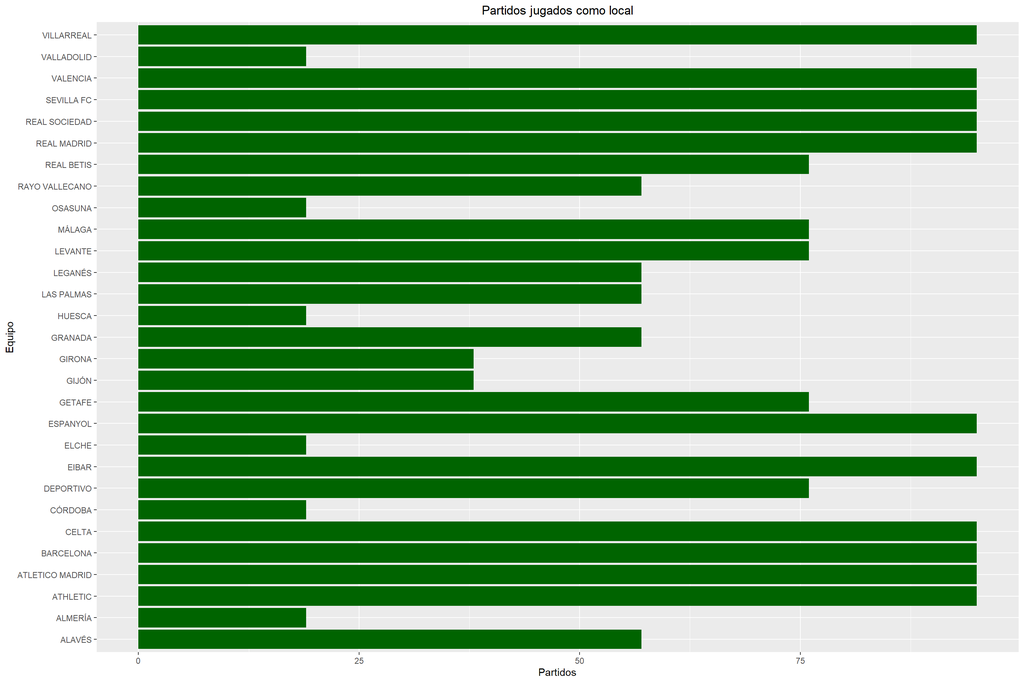

```r
ggplot(train, aes(Home_Team)) +
  geom_bar(fill = "darkgreen") +
  coord_flip() +
  labs(x = "Equipo", y = "Partidos", title = "Partidos jugados como local") +
  theme(plot.title = element_text(hjust = 0.5))
```

Tanto en el análisis numérico como en la gráfica podemos observar que hay algunos equipos que han jugado todos los partidos posibles, mientras que otros no, lo cual nos indica aquellos que han estado al menos una temporada en segunda división.

Respecto a los resultados, se puede ver a continuación cómo el equipo local gana prácticamente la mitad de los partidos (46.42%), por un 28.95% de victorias visitantes y un 24.63% de empates.

```r
# Número y proporción de victorias, derrotas y empates
table(train$score)
```

```
##
##   1   x   2
## 882 468 550
```

```r
round(prop.table(table(train$score))*100, 2)
```

```
##
##     1     x     2
## 46.42 24.63 28.95
```

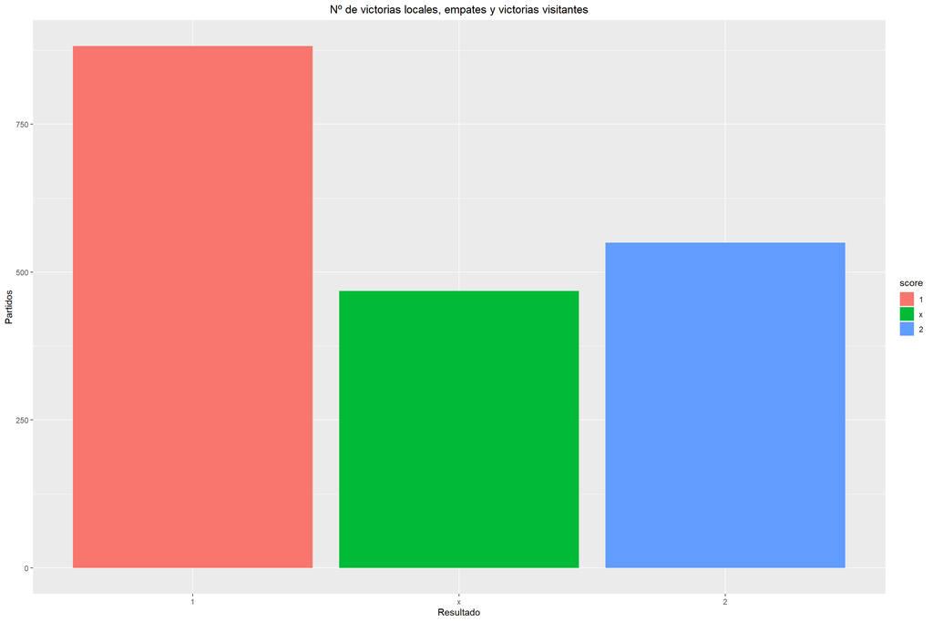

```r
ggplot(train, aes(score, fill = score)) +
  geom_bar() +
  labs(x = "Resultado", y = "Partidos", title = "Nº de victorias locales, empates y victorias visitantes") +
  theme(plot.title = element_text(hjust = 0.5))
```

Tras haber analizado ambas variables por separado, a continuación se hará de forma conjunta, mostrando la cantidad y la proporción de partidos que cada equipo gana, empate y pierde dependiendo de si es local o visitante (en ese orden).

```r
# Partidos ganados, empatados y perdidos por cada equipo como local
with(train, table(Home_Team, score)) %>%
  kbl() %>%
  kable_material(c("striped", "hover")) %>%
  scroll_box(width = "100%", height = "350px")
```

|  | 1 | x | 2 |
| --- | --- | --- | --- |
| ALAVÉS | 23 | 17 | 17 |
| ALMERÍA | 3 | 7 | 9 |
| ATHLETIC | 47 | 30 | 18 |
| ATLETICO MADRID | 70 | 17 | 8 |
| BARCELONA | 78 | 11 | 6 |
| CÁDIZ CF | 0 | 0 | 0 |
| CELTA | 42 | 26 | 27 |
| CÓRDOBA | 1 | 6 | 12 |
| DEPORTIVO | 20 | 25 | 31 |
| EIBAR | 40 | 21 | 34 |
| ELCHE | 6 | 3 | 10 |
| ESPANYOL | 44 | 25 | 26 |
| GETAFE | 32 | 19 | 25 |
| GIJÓN | 12 | 8 | 18 |
| GIRONA | 11 | 9 | 18 |
| GRANADA | 14 | 19 | 24 |
| HUESCA | 5 | 6 | 8 |
| LAS PALMAS | 21 | 13 | 23 |
| LEGANÉS | 21 | 18 | 18 |
| LEVANTE | 26 | 24 | 26 |
| MÁLAGA | 30 | 17 | 29 |
| MALLORCA | 0 | 0 | 0 |
| OSASUNA | 2 | 7 | 10 |
| RAYO VALLECANO | 21 | 12 | 24 |
| REAL BETIS | 30 | 22 | 24 |
| REAL MADRID | 71 | 12 | 12 |
| REAL SOCIEDAD | 43 | 24 | 28 |
| SEVILLA FC | 64 | 18 | 13 |
| VALENCIA | 49 | 27 | 19 |
| VALLADOLID | 5 | 5 | 9 |
| VILLARREAL | 51 | 20 | 24 |

```r
# Partidos ganados, empatados y perdidos por cada equipo como visitante
with(train, table(Away_Team, score)) %>%
  kbl() %>%
  kable_material(c("striped", "hover")) %>%
  scroll_box(width = "100%", height = "350px")
```

|  | 1 | x | 2 |
| --- | --- | --- | --- |
| ALAVÉS | 29 | 9 | 19 |
| ALMERÍA | 13 | 1 | 5 |
| ATHLETIC | 46 | 21 | 28 |
| ATLETICO MADRID | 21 | 25 | 49 |
| BARCELONA | 11 | 21 | 63 |
| CÁDIZ CF | 0 | 0 | 0 |
| CELTA | 49 | 22 | 24 |
| CÓRDOBA | 12 | 5 | 2 |
| DEPORTIVO | 37 | 30 | 9 |
| EIBAR | 46 | 29 | 20 |
| ELCHE | 9 | 5 | 5 |
| ESPANYOL | 46 | 27 | 22 |
| GETAFE | 38 | 21 | 17 |
| GIJÓN | 22 | 11 | 5 |
| GIRONA | 16 | 10 | 12 |
| GRANADA | 38 | 12 | 7 |
| HUESCA | 11 | 6 | 2 |
| LAS PALMAS | 40 | 11 | 6 |
| LEGANÉS | 35 | 12 | 10 |
| LEVANTE | 45 | 18 | 13 |
| MÁLAGA | 45 | 18 | 13 |
| MALLORCA | 0 | 0 | 0 |
| OSASUNA | 14 | 3 | 2 |
| RAYO VALLECANO | 35 | 11 | 11 |
| REAL BETIS | 40 | 13 | 23 |
| REAL MADRID | 19 | 17 | 59 |
| REAL SOCIEDAD | 45 | 23 | 27 |
| SEVILLA FC | 44 | 23 | 28 |
| VALENCIA | 36 | 25 | 34 |
| VALLADOLID | 8 | 6 | 5 |
| VILLARREAL | 32 | 33 | 30 |

```r
# Proporción de partidos ganados, empatados y perdidos por cada equipo como local
round(t((prop.table(with(train, table(score, Home_Team)), margin = 2)))*100,2) %>%
  kbl() %>%
  kable_material(c("striped", "hover")) %>%
  scroll_box(width = "100%", height = "350px")
```

|  | 1 | x | 2 |
| --- | --- | --- | --- |
| ALAVÉS | 40.35 | 29.82 | 29.82 |
| ALMERÍA | 15.79 | 36.84 | 47.37 |
| ATHLETIC | 49.47 | 31.58 | 18.95 |
| ATLETICO MADRID | 73.68 | 17.89 | 8.42 |
| BARCELONA | 82.11 | 11.58 | 6.32 |
| CÁDIZ CF | NaN | NaN | NaN |
| CELTA | 44.21 | 27.37 | 28.42 |
| CÓRDOBA | 5.26 | 31.58 | 63.16 |
| DEPORTIVO | 26.32 | 32.89 | 40.79 |
| EIBAR | 42.11 | 22.11 | 35.79 |
| ELCHE | 31.58 | 15.79 | 52.63 |
| ESPANYOL | 46.32 | 26.32 | 27.37 |
| GETAFE | 42.11 | 25.00 | 32.89 |
| GIJÓN | 31.58 | 21.05 | 47.37 |
| GIRONA | 28.95 | 23.68 | 47.37 |
| GRANADA | 24.56 | 33.33 | 42.11 |
| HUESCA | 26.32 | 31.58 | 42.11 |
| LAS PALMAS | 36.84 | 22.81 | 40.35 |
| LEGANÉS | 36.84 | 31.58 | 31.58 |
| LEVANTE | 34.21 | 31.58 | 34.21 |
| MÁLAGA | 39.47 | 22.37 | 38.16 |
| MALLORCA | NaN | NaN | NaN |
| OSASUNA | 10.53 | 36.84 | 52.63 |
| RAYO VALLECANO | 36.84 | 21.05 | 42.11 |
| REAL BETIS | 39.47 | 28.95 | 31.58 |
| REAL MADRID | 74.74 | 12.63 | 12.63 |
| REAL SOCIEDAD | 45.26 | 25.26 | 29.47 |
| SEVILLA FC | 67.37 | 18.95 | 13.68 |
| VALENCIA | 51.58 | 28.42 | 20.00 |
| VALLADOLID | 26.32 | 26.32 | 47.37 |
| VILLARREAL | 53.68 | 21.05 | 25.26 |

```r
# Proporción de partidos ganados, empatados y perdidos por cada equipo como visitante
round(t((prop.table(with(train, table(score, Away_Team)), margin = 2)))*100,2) %>%
  kbl() %>%
  kable_material(c("striped", "hover")) %>%
  scroll_box(width = "100%", height = "350px")
```

|  | 1 | x | 2 |
| --- | --- | --- | --- |
| ALAVÉS | 50.88 | 15.79 | 33.33 |
| ALMERÍA | 68.42 | 5.26 | 26.32 |
| ATHLETIC | 48.42 | 22.11 | 29.47 |
| ATLETICO MADRID | 22.11 | 26.32 | 51.58 |
| BARCELONA | 11.58 | 22.11 | 66.32 |
| CÁDIZ CF | NaN | NaN | NaN |
| CELTA | 51.58 | 23.16 | 25.26 |
| CÓRDOBA | 63.16 | 26.32 | 10.53 |
| DEPORTIVO | 48.68 | 39.47 | 11.84 |
| EIBAR | 48.42 | 30.53 | 21.05 |
| ELCHE | 47.37 | 26.32 | 26.32 |
| ESPANYOL | 48.42 | 28.42 | 23.16 |
| GETAFE | 50.00 | 27.63 | 22.37 |
| GIJÓN | 57.89 | 28.95 | 13.16 |
| GIRONA | 42.11 | 26.32 | 31.58 |
| GRANADA | 66.67 | 21.05 | 12.28 |
| HUESCA | 57.89 | 31.58 | 10.53 |
| LAS PALMAS | 70.18 | 19.30 | 10.53 |
| LEGANÉS | 61.40 | 21.05 | 17.54 |
| LEVANTE | 59.21 | 23.68 | 17.11 |
| MÁLAGA | 59.21 | 23.68 | 17.11 |
| MALLORCA | NaN | NaN | NaN |
| OSASUNA | 73.68 | 15.79 | 10.53 |
| RAYO VALLECANO | 61.40 | 19.30 | 19.30 |
| REAL BETIS | 52.63 | 17.11 | 30.26 |
| REAL MADRID | 20.00 | 17.89 | 62.11 |
| REAL SOCIEDAD | 47.37 | 24.21 | 28.42 |
| SEVILLA FC | 46.32 | 24.21 | 29.47 |
| VALENCIA | 37.89 | 26.32 | 35.79 |
| VALLADOLID | 42.11 | 31.58 | 26.32 |
| VILLARREAL | 33.68 | 34.74 | 31.58 |

También se muestra la visualización de estos datos para una comprensión mas intuitiva:

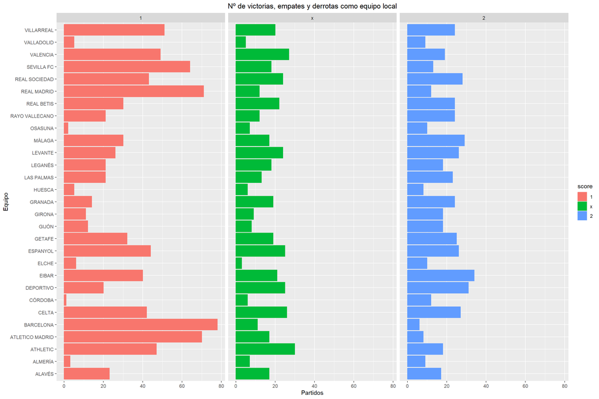

```r
ggplot(train, aes(x = Home_Team, color = score, fill = score)) + geom_bar() + facet_wrap(~score) + coord_flip() + labs(x = "Equipo", y = "Partidos", title = "Nº de victorias, empates y derrotas como equipo local")+ theme(plot.title = element_text(hjust = 0.5))
```

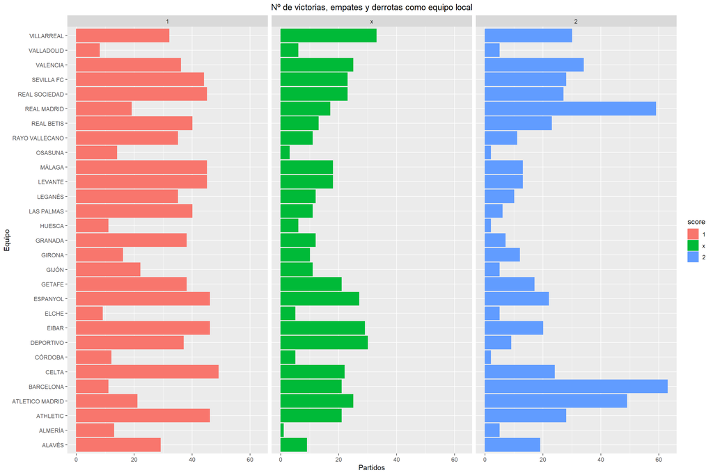

```r
ggplot(train, aes(x = Away_Team, color = score, fill = score)) + geom_bar() + facet_wrap(~score) + coord_flip() + labs(x = "Equipo", y = "Partidos", title = "Nº de victorias, empates y derrotas como equipo local")+ theme(plot.title = element_text(hjust = 0.5))
```

Es interesante ver como, tras este análisis de las variables cualitativas ya se pueden identificar los equipos punteros de la liga.

No sólo hay 11 equipos que se han mantenido en primera todos los años (Athletic, Atlético, Barcelona, Celta, Eibar, Espanyol, Real Madrid, Real Sociedad, Sevilla, Valencia y Villarreal) si no que algunos de ellos cosechan una mayor proporción de victorias.

En este grupo destacan sobre el resto los tres “grandes” de la actualidad (Real Madrid, Barcelona y Atlético), ya que aunque en partidos como local hay alguno equipo (como el Sevilla) que se les acerca en victorias, es en los partidos como visitante donde estos tres destacan por encima del resto (especialmente Madrid y Barcelona).

Lo cual tiene especial relevancia si comparamos estos datos con los del inicio, en los que se veía que jugar en casa era un factor determinante para ganar un partido.

Por lo tanto, un buen indicio para saber cómo de bueno es un equipo es ver su proporción de victorias como visitante.

# 4 Análisis de las variables cuantitativas

En el caso de las variables cuantitativas tenemos una gran cantidad de ellas para analizar, así que para un mejor entendimiento de las mismas se analizarán agrupándolas por eventos similares en el partido y comparándolas entre equipo local y visitante, tanto numérica como visualmente con gráficos de cajas.

```r
# Posesion
bind_rows(data.frame(summarise(train,
                               max = max(`Home_Team_Possession_%`),
                               min = min(`Home_Team_Possession_%`),
                               mean = mean(`Home_Team_Possession_%`),
                               sd = sd(`Home_Team_Possession_%`))),
          data.frame(summarise(train,
                               max = max(`Away_Team_Possession_%`),
                               min = min(`Away_Team_Possession_%`),
                               mean = mean(`Away_Team_Possession_%`),
                               sd = sd(`Away_Team_Possession_%`)))
          ) %>% mutate("Posesión (%)" = c("Local", "Visitante")) %>%
  select("Posesión (%)", everything()) %>%
  kbl() %>%
  kable_material(c("striped", "hover"))
```

| Posesión (%) | max | min | mean | sd |
| --- | --- | --- | --- | --- |
| Local | 82 | 19 | 51.73526 | 10.81677 |
| Visitante | 81 | 18 | 48.25789 | 10.82105 |

```r
# Pases
bind_rows(data.frame(summarise(train,
                               max = max(`Home_Team_Pass_Success_%`),
                               min = min(`Home_Team_Pass_Success_%`),
                               mean = mean(`Home_Team_Pass_Success_%`),
                               sd = sd(`Home_Team_Pass_Success_%`))),
          data.frame(summarise(train,
                               max = max(`Away_Team_Pass_Success_%`),
                               min = min(`Away_Team_Pass_Success_%`),
                               mean = mean(`Away_Team_Pass_Success_%`),
                               sd = sd(`Away_Team_Pass_Success_%`)))
          ) %>% mutate("Pases acertados (%)" = c("Local", "Visitante")) %>%
  select("Pases acertados (%)", everything()) %>%
  kbl() %>%
  kable_material(c("striped", "hover"))
```

| Pases acertados (%) | max | min | mean | sd |
| --- | --- | --- | --- | --- |
| Local | 93 | 46 | 77.68316 | 7.486947 |
| Visitante | 93 | 41 | 75.73737 | 7.947165 |

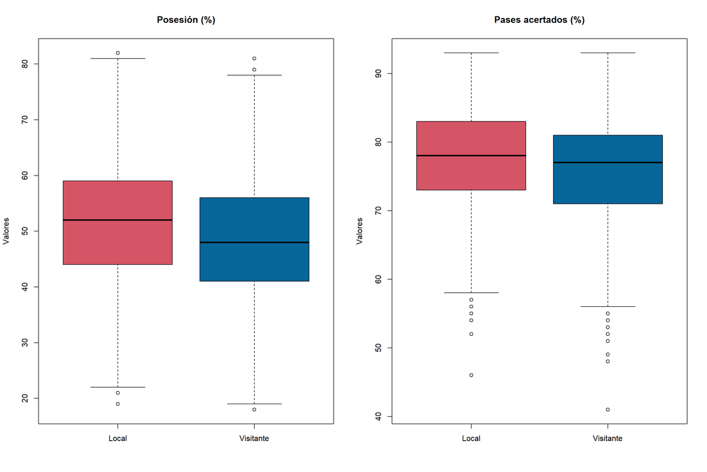

```r
par(mfrow = c(1, 2))
boxplot(train$`Home_Team_Possession_%`, train$`Away_Team_Possession_%`, main = 'Posesión (%)',
        ylab = "Valores", col = c("#d55566","#066699"))
axis(1, at = 1:2, labels = c("Local", "Visitante"))

boxplot(train$`Home_Team_Pass_Success_%`, train$`Away_Team_Pass_Success_%`, main = 'Pases acertados (%)',
        ylab = "Valores", col = c("#d55566","#066699"))
axis(1, at = 1:2, labels = c("Local", "Visitante"))
```

En términos de posesión y porcentaje de pases acertados (dos variables lógicamente relacionadas), se observa como ambas distribuciones son prácticamente calcadas, con valores ligeramente más altos para el equipo local peri sin diferencias significativas.

```r
# Tiros
bind_rows(data.frame(summarise(train,
                               max = max(Home_Team_Total_Shots),
                               min = min(Home_Team_Total_Shots),
                               mean = mean(Home_Team_Total_Shots),
                               sd = sd(Home_Team_Total_Shots))),
          data.frame(summarise(train,
                               max = max(Away_Team_Total_Shots),
                               min = min(Away_Team_Total_Shots),
                               mean = mean(Away_Team_Total_Shots),
                               sd = sd(Away_Team_Total_Shots)))
          ) %>% mutate("Tiros" = c("Local", "Visitante")) %>%
  select("Tiros", everything()) %>%
  kbl() %>%
  kable_material(c("striped", "hover"))
```

| Tiros | max | min | mean | sd |
| --- | --- | --- | --- | --- |
| Local | 33 | 2 | 13.53421 | 4.760000 |
| Visitante | 28 | 0 | 10.49158 | 4.296837 |

```r
# Tiros a puerta
bind_rows(data.frame(summarise(train,
                               max = max(Home_Team_On_Target_Shots),
                               min = min(Home_Team_On_Target_Shots),
                               mean = mean(Home_Team_On_Target_Shots),
                               sd = sd(Home_Team_On_Target_Shots))),
          data.frame(summarise(train,
                               max = max(Away_Team_On_Target_Shots),
                               min = min(Away_Team_On_Target_Shots),
                               mean = mean(Away_Team_On_Target_Shots),
                               sd = sd(Away_Team_On_Target_Shots)))
          ) %>% mutate("Tiros a puerta" = c("Local", "Visitante")) %>%
  select("Tiros a puerta", everything()) %>%
  kbl() %>%
  kable_material(c("striped", "hover"))
```

| Tiros a puerta | max | min | mean | sd |
| --- | --- | --- | --- | --- |
| Local | 15 | 0 | 4.841053 | 2.536931 |
| Visitante | 13 | 0 | 3.747895 | 2.185722 |

```r
# Tiros fuera
bind_rows(data.frame(summarise(train,
                               max = max(Home_Team_Off_Target_Shots),
                               min = min(Home_Team_Off_Target_Shots),
                               mean = mean(Home_Team_Off_Target_Shots),
                               sd = sd(Home_Team_Off_Target_Shots))),
          data.frame(summarise(train,
                               max = max(Away_Team_Off_Target_Shots),
                               min = min(Away_Team_Off_Target_Shots),
                               mean = mean(Away_Team_Off_Target_Shots),
                               sd = sd(Away_Team_Off_Target_Shots)))
          ) %>% mutate("Tiros fuera" = c("Local", "Visitante")) %>%
  select("Tiros fuera", everything()) %>%
  kbl() %>%
  kable_material(c("striped", "hover"))
```

| Tiros fuera | max | min | mean | sd |
| --- | --- | --- | --- | --- |
| Local | 17 | 0 | 5.721579 | 2.669599 |
| Visitante | 14 | 0 | 4.352632 | 2.339952 |

```r
# Tiros bloqueados
bind_rows(data.frame(summarise(train,
                               max = max(Home_Team_Blocked_Shots),
                               min = min(Home_Team_Blocked_Shots),
                               mean = mean(Home_Team_Blocked_Shots),
                               sd = sd(Home_Team_Blocked_Shots))),
          data.frame(summarise(train,
                               max = max(Away_Team_Blocked_Shots),
                               min = min(Away_Team_Blocked_Shots),
                               mean = mean(Away_Team_Blocked_Shots),
                               sd = sd(Away_Team_Blocked_Shots)))
          ) %>% mutate("Tiros bloqueados" = c("Local", "Visitante")) %>%
  select("Tiros bloqueados", everything()) %>%
  kbl() %>%
  kable_material(c("striped", "hover"))
```

| Tiros bloqueados | max | min | mean | sd |
| --- | --- | --- | --- | --- |
| Local | 12 | 0 | 2.981579 | 1.991604 |
| Visitante | 11 | 0 | 2.410526 | 1.837212 |

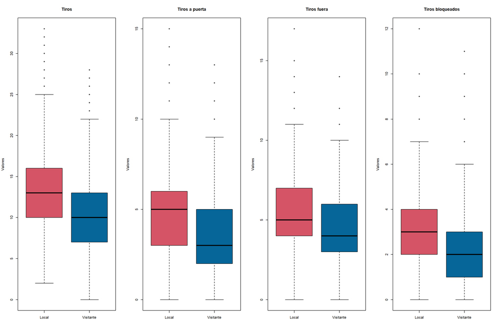

```r
par(mfrow = c(1, 4))
boxplot(train$Home_Team_Total_Shots, train$Away_Team_Total_Shots, main = 'Tiros',
        ylab = "Valores", col = c("#d55566","#066699"))
axis(1, at = 1:2, labels = c("Local", "Visitante"))

boxplot(train$Home_Team_On_Target_Shots, train$Away_Team_On_Target_Shots, main = 'Tiros a puerta',
        ylab = "Valores", col = c("#d55566","#066699"))
axis(1, at = 1:2, labels = c("Local", "Visitante"))

boxplot(train$Home_Team_Off_Target_Shots, train$Away_Team_Off_Target_Shots, main = 'Tiros fuera',
        ylab = "Valores", col = c("#d55566","#066699"))
axis(1, at = 1:2, labels = c("Local", "Visitante"))

boxplot(train$Home_Team_Blocked_Shots, train$Away_Team_Blocked_Shots, main = 'Tiros bloqueados',
        ylab = "Valores", col = c("#d55566","#066699"))
axis(1, at = 1:2, labels = c("Local", "Visitante"))
```

En el apartado de tiros vemos como el equipo local sí es dominador en todas las facetas. Y aunque las diferencias no son enormes, sí que parecen suficientes para marcar diferencias (como así lo hacen en el marcador).

```r
# Corners
bind_rows(data.frame(summarise(train,
                               max = max(Home_Team_Corners),
                               min = min(Home_Team_Corners),
                               mean = mean(Home_Team_Corners),
                               sd = sd(Home_Team_Corners))),
          data.frame(summarise(train,
                               max = max(Away_Team_Corners),
                               min = min(Away_Team_Corners),
                               mean = mean(Away_Team_Corners),
                               sd = sd(Away_Team_Corners)))
          ) %>% mutate("Corners" = c("Local", "Visitante")) %>%
  select("Corners", everything()) %>%
  kbl() %>%
  kable_material(c("striped", "hover"))
```

| Corners | max | min | mean | sd |
| --- | --- | --- | --- | --- |
| Local | 20 | 0 | 5.657895 | 2.860605 |
| Visitante | 32 | 0 | 4.202632 | 2.523923 |

```r
# Centros
bind_rows(data.frame(summarise(train,
                               max = max(Home_Team_Throw_Ins),
                               min = min(Home_Team_Throw_Ins),
                               mean = mean(Home_Team_Throw_Ins),
                               sd = sd(Home_Team_Throw_Ins))),
          data.frame(summarise(train,
                               max = max(Away_Team_Throw_Ins),
                               min = min(Away_Team_Throw_Ins),
                               mean = mean(Away_Team_Throw_Ins),
                               sd = sd(Away_Team_Throw_Ins)))
          ) %>% mutate("Centros" = c("Local", "Visitante")) %>%
  select("Centros", everything()) %>%
  kbl() %>%
  kable_material(c("striped", "hover"))
```

| Centros | max | min | mean | sd |
| --- | --- | --- | --- | --- |
| Local | 47 | 5 | 22.84368 | 6.795616 |
| Visitante | 45 | 3 | 21.61526 | 6.477398 |

```r
# Balones aereos
bind_rows(data.frame(summarise(train,
                               max = max(Home_Team_Aerials_Won),
                               min = min(Home_Team_Aerials_Won),
                               mean = mean(Home_Team_Aerials_Won),
                               sd = sd(Home_Team_Aerials_Won))),
          data.frame(summarise(train,
                               max = max(Away_Team_Aerials_Won),
                               min = min(Away_Team_Aerials_Won),
                               mean = mean(Away_Team_Aerials_Won),
                               sd = sd(Away_Team_Aerials_Won)))
          ) %>% mutate("Balones aereos ganados" = c("Local", "Visitante")) %>%
  select("Balones aereos ganados", everything()) %>%
  kbl() %>%
  kable_material(c("striped", "hover"))
```

| Balones aereos ganados | max | min | mean | sd |
| --- | --- | --- | --- | --- |
| Local | 46 | 2 | 16.61579 | 7.241691 |
| Visitante | 47 | 0 | 16.15526 | 6.954876 |

```r
# Despejes
bind_rows(data.frame(summarise(train,
                               max = max(Home_Team_Clearances),
                               min = min(Home_Team_Clearances),
                               mean = mean(Home_Team_Clearances),
                               sd = sd(Home_Team_Clearances))),
          data.frame(summarise(train,
                               max = max(Away_Team_Clearances),
                               min = min(Away_Team_Clearances),
                               mean = mean(Away_Team_Clearances),
                               sd = sd(Away_Team_Clearances)))
          ) %>% mutate("Despejes" = c("Local", "Visitante")) %>%
  select("Despejes", everything()) %>%
  kbl() %>%
  kable_material(c("striped", "hover"))
```

| Despejes | max | min | mean | sd |
| --- | --- | --- | --- | --- |
| Local | 61 | 1 | 18.42684 | 8.404368 |
| Visitante | 63 | 2 | 22.92632 | 9.473326 |

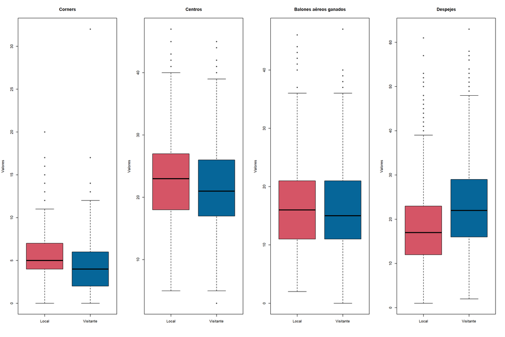

```r
par(mfrow = c(1, 4))
boxplot(train$Home_Team_Corners, train$Away_Team_Corners, main = 'Corners',
        ylab = "Valores", col = c("#d55566","#066699"))
axis(1, at = 1:2, labels = c("Local", "Visitante"))

boxplot(train$Home_Team_Throw_Ins, train$Away_Team_Throw_Ins, main = 'Centros',
        ylab = "Valores", col = c("#d55566","#066699"))
axis(1, at = 1:2, labels = c("Local", "Visitante"))

boxplot(train$Home_Team_Aerials_Won, train$Away_Team_Aerials_Won, main = 'Balones aéreos ganados',
        ylab = "Valores", col = c("#d55566","#066699"))
axis(1, at = 1:2, labels = c("Local", "Visitante"))

boxplot(train$Home_Team_Clearances, train$Away_Team_Clearances, main = 'Despejes',
        ylab = "Valores", col = c("#d55566","#066699"))
axis(1, at = 1:2, labels = c("Local", "Visitante"))
```

Al igual que con los tiros, el equipo local domina también los centros y corners, lo cual quiere decir que tiene mayor presencia en área contraria. Esto encaja con el hecho de que sea el equipo visitante el que más balones despeje.

```r
# Faltas
bind_rows(data.frame(summarise(train,
                               max = max(Home_Team_Fouls),
                               min = min(Home_Team_Fouls),
                               mean = mean(Home_Team_Fouls),
                               sd = sd(Home_Team_Fouls))),
          data.frame(summarise(train,
                               max = max(Away_Team_Fouls),
                               min = min(Away_Team_Fouls),
                               mean = mean(Away_Team_Fouls),
                               sd = sd(Away_Team_Fouls)))
          ) %>% mutate("Faltas" = c("Local", "Visitante")) %>%
  select("Faltas", everything()) %>%
  kbl() %>%
  kable_material(c("striped", "hover"))
```

| Faltas | max | min | mean | sd |
| --- | --- | --- | --- | --- |
| Local | 33 | 1 | 13.84684 | 4.254319 |
| Visitante | 29 | 0 | 13.87526 | 4.187637 |

```r
# Amarillas
bind_rows(data.frame(summarise(train,
                               max = max(Home_Team_Yellow_Cards),
                               min = min(Home_Team_Yellow_Cards),
                               mean = mean(Home_Team_Yellow_Cards),
                               sd = sd(Home_Team_Yellow_Cards))),
          data.frame(summarise(train,
                               max = max(Away_Team_Yellow_Cards),
                               min = min(Away_Team_Yellow_Cards),
                               mean = mean(Away_Team_Yellow_Cards),
                               sd = sd(Away_Team_Yellow_Cards)))
          ) %>% mutate("Tarjetas amarillas" = c("Local", "Visitante")) %>%
  select("Tarjetas amarillas", everything()) %>%
  kbl() %>%
  kable_material(c("striped", "hover"))
```

| Tarjetas amarillas | max | min | mean | sd |
| --- | --- | --- | --- | --- |
| Local | 8 | 0 | 2.460526 | 1.521833 |
| Visitante | 8 | 0 | 2.744210 | 1.485703 |

```r
# Segundas amarillas
bind_rows(data.frame(summarise(train,
                               max = max(Home_Team_Second_Yellow_Cards),
                               min = min(Home_Team_Second_Yellow_Cards),
                               mean = mean(Home_Team_Second_Yellow_Cards),
                               sd = sd(Home_Team_Second_Yellow_Cards))),
          data.frame(summarise(train,
                               max = max(Away_Team_Second_Yellow_Cards),
                               min = min(Away_Team_Second_Yellow_Cards),
                               mean = mean(Away_Team_Second_Yellow_Cards),
                               sd = sd(Away_Team_Second_Yellow_Cards)))
          ) %>% mutate("Segundas tarjetas amarillas" = c("Local", "Visitante")) %>%
  select("Segundas tarjetas amarillas", everything()) %>%
  kbl() %>%
  kable_material(c("striped", "hover"))
```

| Segundas tarjetas amarillas | max | min | mean | sd |
| --- | --- | --- | --- | --- |
| Local | 2 | 0 | 0.0600000 | 0.2462569 |
| Visitante | 2 | 0 | 0.0836842 | 0.2863345 |

```r
# Rojas
bind_rows(data.frame(summarise(train,
                               max = max(Home_Team_Red_Cards),
                               min = min(Home_Team_Red_Cards),
                               mean = mean(Home_Team_Red_Cards),
                               sd = sd(Home_Team_Red_Cards))),
          data.frame(summarise(train,
                               max = max(Away_Team_Red_Cards),
                               min = min(Away_Team_Red_Cards),
                               mean = mean(Away_Team_Red_Cards),
                               sd = sd(Away_Team_Red_Cards)))
          ) %>% mutate("Tarjetas rojas" = c("Local", "Visitante")) %>%
  select("Tarjetas rojas", everything()) %>%
  kbl() %>%
  kable_material(c("striped", "hover"))
```

| Tarjetas rojas | max | min | mean | sd |
| --- | --- | --- | --- | --- |
| Local | 2 | 0 | 0.0442105 | 0.2131614 |
| Visitante | 2 | 0 | 0.0478947 | 0.2255898 |

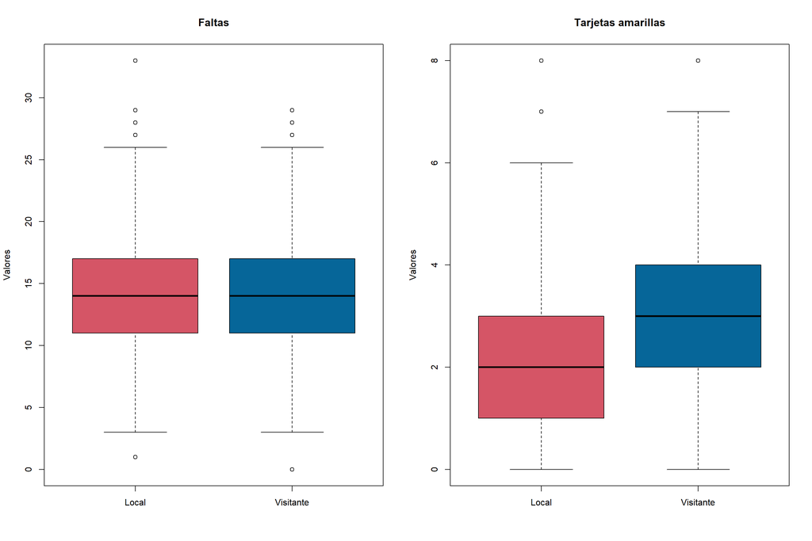

```r
par(mfrow = c(1, 2))
boxplot(train$Home_Team_Fouls, train$Away_Team_Fouls, main = 'Faltas',
        ylab = "Valores", col = c("#d55566","#066699"))
axis(1, at = 1:2, labels = c("Local", "Visitante"))

boxplot(train$Home_Team_Yellow_Cards, train$Away_Team_Yellow_Cards, main = 'Tarjetas amarillas',
        ylab = "Valores", col = c("#d55566","#066699"))
axis(1, at = 1:2, labels = c("Local", "Visitante"))
```

Aunque seguramente influirán otros factores más difíciles de medir como la presión que ejerza el público local sobre el árbitro a la hora de tomar decisiones.

```r
# Goles
bind_rows(data.frame(summarise(train,
                               max = max(Home_Team_Goals_Scored),
                               min = min(Home_Team_Goals_Scored),
                               mean = mean(Home_Team_Goals_Scored),
                               sd = sd(Home_Team_Goals_Scored))),
          data.frame(summarise(train,
                               max = max(Away_Team_Goals_Scored),
                               min = min(Away_Team_Goals_Scored),
                               mean = mean(Away_Team_Goals_Scored),
                               sd = sd(Away_Team_Goals_Scored)))
          ) %>% mutate("Goles" = c("Local", "Visitante")) %>%
  select("Goles", everything()) %>%
  kbl() %>%
  kable_material(c("striped", "hover"))
```

| Goles | max | min | mean | sd |
| --- | --- | --- | --- | --- |
| Local | 10 | 0 | 1.563684 | 1.364813 |
| Visitante | 8 | 0 | 1.161053 | 1.180123 |

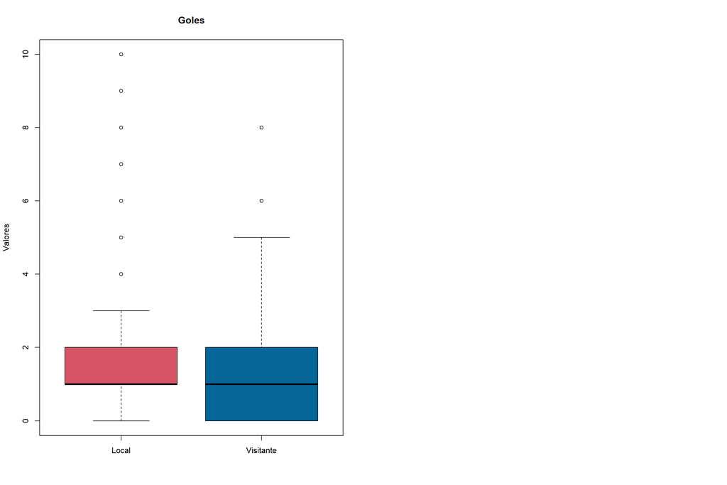

```r
par(mfrow = c(1, 2))
boxplot(train$Home_Team_Goals_Scored, train$Away_Team_Goals_Scored, main = 'Goles',
        ylab = "Valores", col = c("#d55566","#066699"))
axis(1, at = 1:2, labels = c("Local", "Visitante"))
```

Por último se observa que los equipos locales marcan más goles que los visitantes, algo relativamente previsible sabiendo que las victorias suelen caer del lado local.

Para finalizar el análisis univariante a continuación se muestran los histogramas con su curva de densidad de cada una de las variables, donde se aprecia a simple vista en casi todas como siguen una distribución normal.

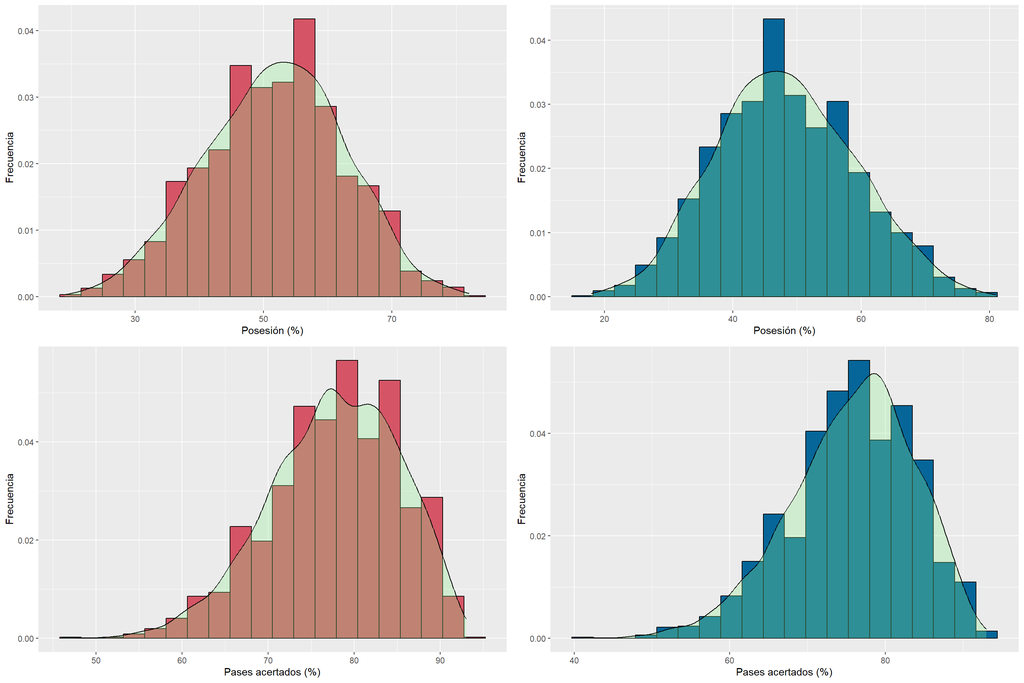

```r
plot_grid(ggplot(train, aes(`Home_Team_Possession_%`)) +
  geom_histogram(aes(y=..density..), bins = 20,position = "dodge", color = 'black', fill = '#d55566') +
  geom_density(alpha=.3, fill = "lightgreen") + labs(x="Posesión (%)", y="Frecuencia") + theme(plot.title=element_text(hjust = 0.5)),

  ggplot(train, aes(`Away_Team_Possession_%`)) +
  geom_histogram(aes(y=..density..), bins = 20,position = "dodge", color = 'black', fill = '#066699') +
  geom_density(alpha=.3, fill = "lightgreen") + labs(x="Posesión (%)", y="Frecuencia") + theme(plot.title=element_text(hjust = 0.5)),

  ggplot(train, aes(`Home_Team_Pass_Success_%`)) +
  geom_histogram(aes(y=..density..), bins = 20, position = "dodge", color = 'black', fill = '#d55566') +
  geom_density(alpha=.3, fill = "lightgreen") + labs(x="Pases acertados (%)", y="Frecuencia") + theme(plot.title=element_text(hjust = 0.5)),

  ggplot(train, aes(`Away_Team_Pass_Success_%`)) +
  geom_histogram(aes(y=..density..), bins = 20,position = "dodge", color = 'black', fill = '#066699') +
  geom_density(alpha=.3, fill = "lightgreen") + labs(x="Pases acertados (%)", y="Frecuencia") + theme(plot.title=element_text(hjust = 0.5)),

        align = "h", ncol = 2, nrow = 2)
```

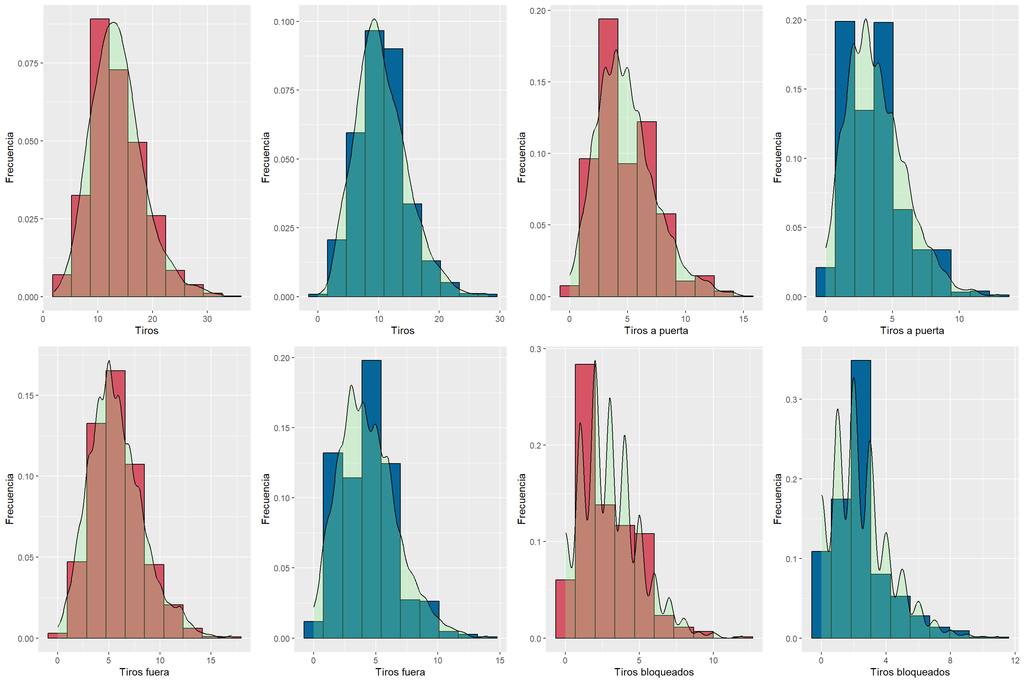

```r
plot_grid(ggplot(train, aes(Home_Team_Total_Shots)) +
  geom_histogram(aes(y=..density..), bins = 10,position = "dodge", color = 'black', fill = '#d55566') +
  geom_density(alpha=.3, fill = "lightgreen") + labs(x="Tiros", y="Frecuencia") + theme(plot.title=element_text(hjust = 0.5)),

  ggplot(train, aes(Away_Team_Total_Shots)) +
  geom_histogram(aes(y=..density..), bins = 10,position = "dodge", color = 'black', fill = '#066699') +
  geom_density(alpha=.3, fill = "lightgreen") + labs(x="Tiros", y="Frecuencia") + theme(plot.title=element_text(hjust = 0.5)),

  ggplot(train, aes(Home_Team_On_Target_Shots)) +
  geom_histogram(aes(y=..density..), bins = 10, position = "dodge", color = 'black', fill = '#d55566') +
  geom_density(alpha=.3, fill = "lightgreen") + labs(x="Tiros a puerta", y="Frecuencia") + theme(plot.title=element_text(hjust = 0.5)),

  ggplot(train, aes(Away_Team_On_Target_Shots)) +
  geom_histogram(aes(y=..density..), bins = 10,position = "dodge", color = 'black', fill = '#066699') +
  geom_density(alpha=.3, fill = "lightgreen") + labs(x="Tiros a puerta", y="Frecuencia") + theme(plot.title=element_text(hjust = 0.5)),

  ggplot(train, aes(Home_Team_Off_Target_Shots)) +
  geom_histogram(aes(y=..density..), bins = 10,position = "dodge", color = 'black', fill = '#d55566') +
  geom_density(alpha=.3, fill = "lightgreen") + labs(x="Tiros fuera", y="Frecuencia") + theme(plot.title=element_text(hjust = 0.5)),

  ggplot(train, aes(Away_Team_Off_Target_Shots)) +
  geom_histogram(aes(y=..density..), bins = 10,position = "dodge", color = 'black', fill = '#066699') +
  geom_density(alpha=.3, fill = "lightgreen") + labs(x="Tiros fuera", y="Frecuencia") + theme(plot.title=element_text(hjust = 0.5)),

  ggplot(train, aes(Home_Team_Blocked_Shots)) +
  geom_histogram(aes(y=..density..), bins = 10,position = "dodge", color = 'black', fill = '#d55566') +
  geom_density(alpha=.3, fill = "lightgreen") + labs(x="Tiros bloqueados", y="Frecuencia") + theme(plot.title=element_text(hjust = 0.5)),

  ggplot(train, aes(Away_Team_Blocked_Shots)) +
  geom_histogram(aes(y=..density..), bins = 10,position = "dodge", color = 'black', fill = '#066699') +
  geom_density(alpha=.3, fill = "lightgreen") + labs(x="Tiros bloqueados", y="Frecuencia") + theme(plot.title=element_text(hjust = 0.5)),

        align = "h", nrow = 2, ncol = 4)
```

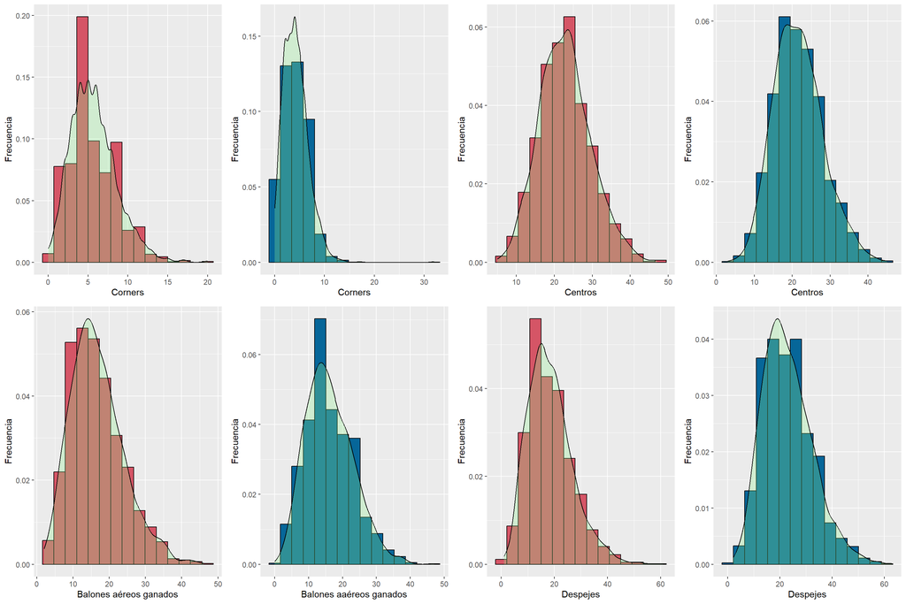

```r
plot_grid(ggplot(train, aes(Home_Team_Corners)) +
  geom_histogram(aes(y=..density..), bins = 15,position = "dodge", color = 'black', fill = '#d55566') +
  geom_density(alpha=.3, fill = "lightgreen") + labs(x="Corners", y="Frecuencia") + theme(plot.title=element_text(hjust = 0.5)),

  ggplot(train, aes(Away_Team_Corners)) +
  geom_histogram(aes(y=..density..), bins = 15,position = "dodge", color = 'black', fill = '#066699') +
  geom_density(alpha=.3, fill = "lightgreen") + labs(x="Corners", y="Frecuencia") + theme(plot.title=element_text(hjust = 0.5)),

  ggplot(train, aes(Home_Team_Throw_Ins)) +
  geom_histogram(aes(y=..density..), bins = 15, position = "dodge", color = 'black', fill = '#d55566') +
  geom_density(alpha=.3, fill = "lightgreen") + labs(x="Centros", y="Frecuencia") + theme(plot.title=element_text(hjust = 0.5)),

  ggplot(train, aes(Away_Team_Throw_Ins)) +
  geom_histogram(aes(y=..density..), bins = 15,position = "dodge", color = 'black', fill = '#066699') +
  geom_density(alpha=.3, fill = "lightgreen") + labs(x="Centros", y="Frecuencia") + theme(plot.title=element_text(hjust = 0.5)),

  ggplot(train, aes(Home_Team_Aerials_Won)) +
  geom_histogram(aes(y=..density..), bins = 15,position = "dodge", color = 'black', fill = '#d55566') +
  geom_density(alpha=.3, fill = "lightgreen") + labs(x="Balones aéreos ganados", y="Frecuencia") + theme(plot.title=element_text(hjust = 0.5)),

  ggplot(train, aes(Away_Team_Aerials_Won)) +
  geom_histogram(aes(y=..density..), bins = 15,position = "dodge", color = 'black', fill = '#066699') +
  geom_density(alpha=.3, fill = "lightgreen") + labs(x="Balones aaéreos ganados", y="Frecuencia") + theme(plot.title=element_text(hjust = 0.5)),

  ggplot(train, aes(Home_Team_Clearances)) +
  geom_histogram(aes(y=..density..), bins = 15,position = "dodge", color = 'black', fill = '#d55566') +
  geom_density(alpha=.3, fill = "lightgreen") + labs(x="Despejes", y="Frecuencia") + theme(plot.title=element_text(hjust = 0.5)),

  ggplot(train, aes(Away_Team_Clearances)) +
  geom_histogram(aes(y=..density..), bins = 15,position = "dodge", color = 'black', fill = '#066699') +
  geom_density(alpha=.3, fill = "lightgreen") + labs(x="Despejes", y="Frecuencia") + theme(plot.title=element_text(hjust = 0.5)),

        align = "h", nrow = 2, ncol = 4)
```

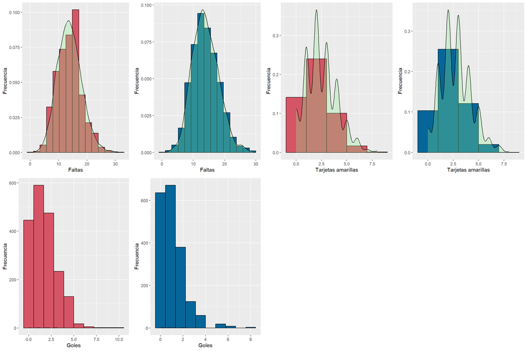

```r
plot_grid(ggplot(train, aes(Home_Team_Fouls)) +
  geom_histogram(aes(y=..density..), bins = 15,position = "dodge", color = 'black', fill = '#d55566') +
  geom_density(alpha=.3, fill = "lightgreen") + labs(x="Faltas", y="Frecuencia") + theme(plot.title=element_text(hjust = 0.5)),

  ggplot(train, aes(Away_Team_Fouls)) +
  geom_histogram(aes(y=..density..), bins = 15,position = "dodge", color = 'black', fill = '#066699') +
  geom_density(alpha=.3, fill = "lightgreen") + labs(x="Faltas", y="Frecuencia") + theme(plot.title=element_text(hjust = 0.5)),

  ggplot(train, aes(Home_Team_Yellow_Cards)) +
  geom_histogram(aes(y=..density..), bins = 5, position = "dodge", color = 'black', fill = '#d55566') +
  geom_density(alpha=.3, fill = "lightgreen") + labs(x="Tarjetas amarillas", y="Frecuencia") + theme(plot.title=element_text(hjust = 0.5)),

  ggplot(train, aes(Away_Team_Yellow_Cards)) +
  geom_histogram(aes(y=..density..), bins = 5,position = "dodge", color = 'black', fill = '#066699') +
  geom_density(alpha=.3, fill = "lightgreen") + labs(x="Tarjetas amarillas", y="Frecuencia") + theme(plot.title=element_text(hjust = 0.5)),

  ggplot(train, aes(Home_Team_Goals_Scored)) +
  geom_histogram(aes(), bins = 10,position = "dodge", color = 'black', fill = '#d55566') +
  geom_density(alpha=.3, fill = "lightgreen") + labs(x="Goles", y="Frecuencia") + theme(plot.title=element_text(hjust = 0.5)),

  ggplot(train, aes(Away_Team_Goals_Scored)) +
  geom_histogram(aes(), bins = 10,position = "dodge", color = 'black', fill = '#066699') +
  geom_density(alpha=.3, fill = "lightgreen") + labs(x="Goles", y="Frecuencia") + theme(plot.title=element_text(hjust = 0.5)),

        align = "h", nrow = 2, ncol = 4)
```

Sin embargo en el caso de los goles no parece tan evidente que la distribución sea normal (más bien parece una exponencial). Para comprobarlo recurrimos a un gráfico Q-Q Plot.

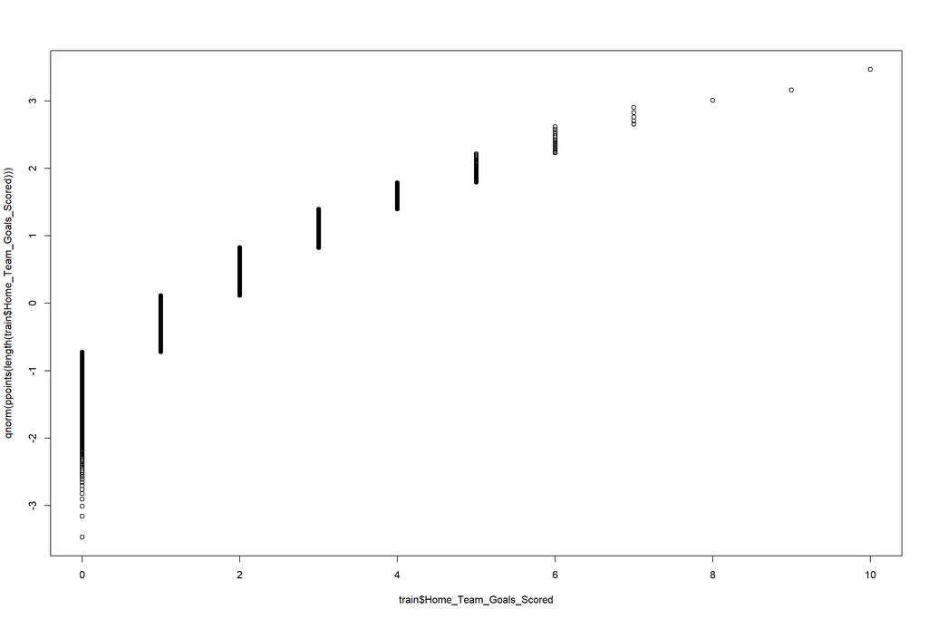

```r
# QQPlot para comprobar su normalidad
qqplot(train$Home_Team_Goals_Scored, qnorm(ppoints(length(train$Home_Team_Goals_Scored))))
```

Como sospechábamos la función no es normal (debería salir aproximadamente una recta en el gráfico Q-Q Plot).

A continuación se muestra, comparándola con una exponencial, como en este caso sí se asemeja más.

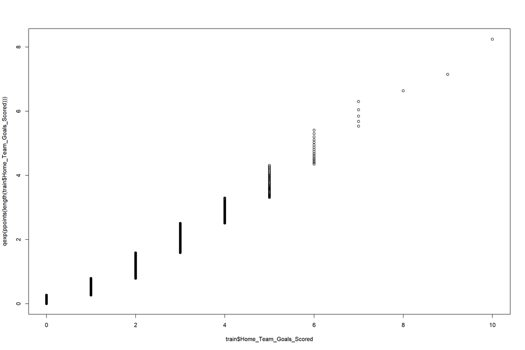

```r
# QQPlot para comprobar si es exponencial
qqplot(train$Home_Team_Goals_Scored, qexp(ppoints(length(train$Home_Team_Goals_Scored))))
```

El resto de variables sí se distribuyen de forma normal, como se ve, por ejemplo, en el Q-Q Plot de la posesión (por elegir alguno):

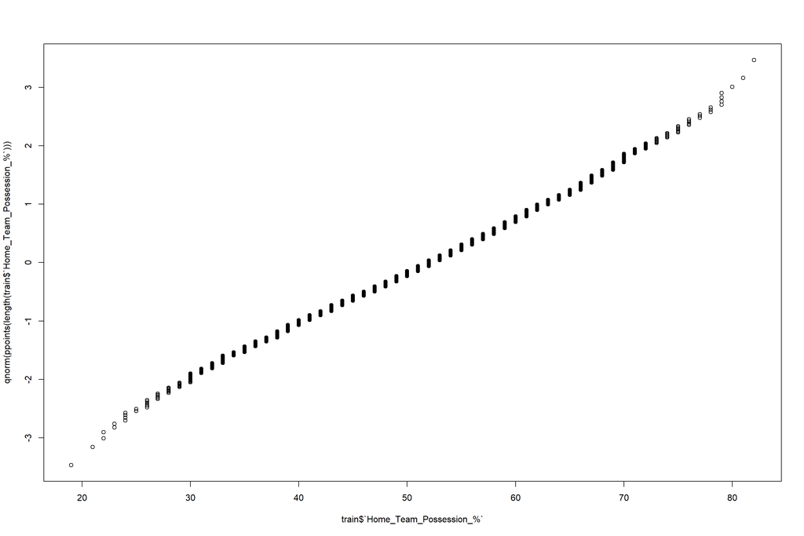

```r
qqplot(train$`Home_Team_Possession_%`, qnorm(ppoints(length(train$`Home_Team_Possession_%`))))
```

# 5 Análisis multivariante

Una vez analizadas todas las variables de forma individual, vamos a buscar las relaciones que hay entre ellas en los siguientes gráficos.

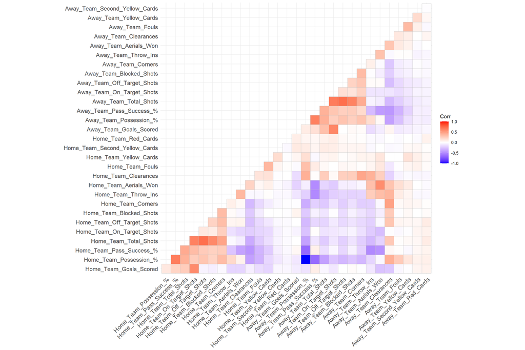

```r
num_data <- train %>% select("Home_Team_Goals_Scored", "Home_Team_Possession_%", "Home_Team_Pass_Success_%", "Home_Team_Total_Shots", "Home_Team_On_Target_Shots", "Home_Team_Off_Target_Shots", "Home_Team_Blocked_Shots", "Home_Team_Corners", "Home_Team_Throw_Ins", "Home_Team_Aerials_Won", "Home_Team_Clearances", "Home_Team_Fouls", "Home_Team_Yellow_Cards", "Home_Team_Second_Yellow_Cards", "Home_Team_Red_Cards", "Away_Team_Goals_Scored", "Away_Team_Possession_%", "Away_Team_Pass_Success_%", "Away_Team_Total_Shots", "Away_Team_On_Target_Shots", "Away_Team_Off_Target_Shots", "Away_Team_Blocked_Shots", "Away_Team_Corners", "Away_Team_Throw_Ins", "Away_Team_Aerials_Won", "Away_Team_Clearances", "Away_Team_Fouls", "Away_Team_Yellow_Cards", "Away_Team_Second_Yellow_Cards", "Away_Team_Red_Cards")

ggcorrplot(cor(num_data),type = "lower", lab=FALSE)
```

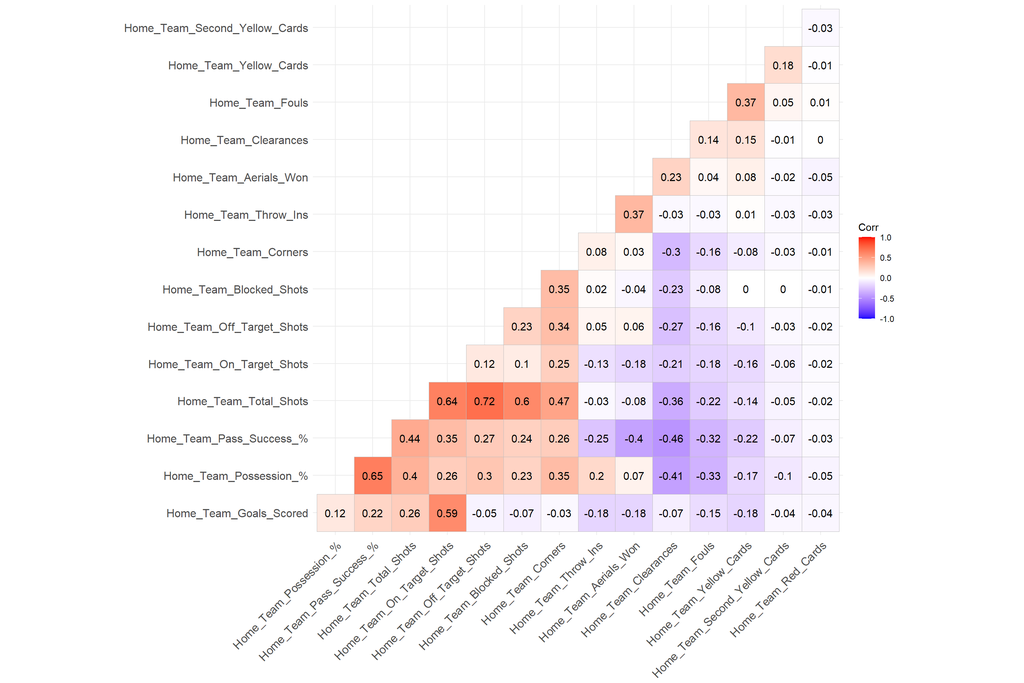

```r
num_data <- train %>% select("Home_Team_Goals_Scored", "Home_Team_Possession_%", "Home_Team_Pass_Success_%", "Home_Team_Total_Shots", "Home_Team_On_Target_Shots", "Home_Team_Off_Target_Shots", "Home_Team_Blocked_Shots", "Home_Team_Corners", "Home_Team_Throw_Ins", "Home_Team_Aerials_Won", "Home_Team_Clearances", "Home_Team_Fouls", "Home_Team_Yellow_Cards", "Home_Team_Second_Yellow_Cards", "Home_Team_Red_Cards")

ggcorrplot(cor(num_data),type = "lower", lab=TRUE)
```

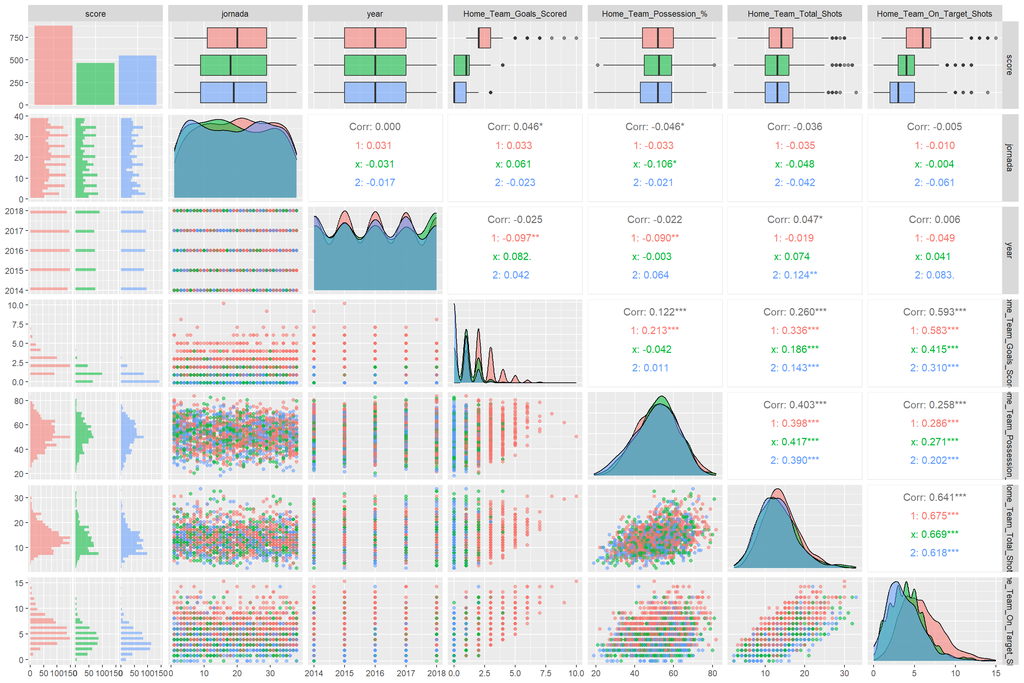

```r
train %>% select("score", "jornada", "year", "Home_Team_Goals_Scored", "Home_Team_Possession_%", "Home_Team_Total_Shots", "Home_Team_On_Target_Shots") %>%
  ggpairs(aes(color = score, alpha = .5))
```

# 6 Modelo de regresión lineal multiple

```r
train <- mutate(train, goals = Home_Team_Goals_Scored + Away_Team_Goals_Scored)
train <- mutate(train, total_off_target_shots = Home_Team_Off_Target_Shots + Away_Team_Off_Target_Shots)
train <- mutate(train, total_on_target_shots = Home_Team_On_Target_Shots + Away_Team_On_Target_Shots)
train <- mutate(train, total_shots = Home_Team_Total_Shots + Away_Team_Total_Shots)
train <- mutate(train, total_blocked_shots = Home_Team_Blocked_Shots + Away_Team_Blocked_Shots)
train <- mutate(train, total_corners = Home_Team_Corners + Away_Team_Corners)
train <- mutate(train, total_throw_ins = Home_Team_Throw_Ins + Away_Team_Throw_Ins)
train <- mutate(train, total_pass_success = `Home_Team_Pass_Success_%` + `Away_Team_Pass_Success_%`)
train <- mutate(train, total_aerials_won = Home_Team_Aerials_Won + Away_Team_Aerials_Won)
train <- mutate(train, total_clearances = Home_Team_Clearances + Away_Team_Clearances)
train <- mutate(train, total_fouls = Home_Team_Fouls + Away_Team_Fouls)
train <- mutate(train, total_yellow_cards = Home_Team_Yellow_Cards + Away_Team_Yellow_Cards)
train <- mutate(train, total_second_yellow_cards = Home_Team_Second_Yellow_Cards + Away_Team_Second_Yellow_Cards)
train <- mutate(train, total_red_cards = Home_Team_Red_Cards + Away_Team_Red_Cards)
```